`— title: “Analiza podataka teniskih mečeva” author: Antonio Babić, Iva Maria Ivanković, Gabrijel Jambrošić, Antun Jurelinac date: 14. siječanj 2022. output: pdf_document —

Ucitavamo podatke.

```r
tennis <- read.csv("tennis_atp_matches.csv")
```

1. Mozemo li nesto zakljuciti iz distribucije visine najboljih deset igraca u posljednjih 30 godina u odnosu na distribuciju visine igraca koji nisu bili tako uspjesni?

Kreiramo novu tablicu u koju rangiramo igrace po broju pobjeda, za pocetak. Raspravljali smo o tome da ih rangiramo po postotku pobjeda, ali to nema smisla zbog toga sto netko npr. moze imati 2/2 pobjede, a netko 19/20. (Postaviti pitanje asistentu.)

```r
pobjednici <- tennis[c("winner_id", "winner_name", "winner_ht")]
grupiraniPobjednici <- subset(as.data.frame(table(pobjednici)), Freq != 0)
colnames(grupiraniPobjednici) <- c("player_id", "player_name", "player_ht", "no_of_wins")
sortiraniPobjednici <- grupiraniPobjednici[order(grupiraniPobjednici$no_of_wins, decreasing = TRUE),]
desetNajboljih <- head(sortiraniPobjednici, 10)
```

Problem se pojavio kod traženja igrača koji nisu bili tako uspješni. Naime, nema smisla rangirati ih po najmanjem broju pobjeda, jer će biti puno igrača s 0 ili 1 pobjedom. Isto tako, rangiranje po najmanjem postotku pobjeda ne bi bilo baš sretno rješenje. Iz tog razloga, rangiramo ih po najvećem broju gubitaka i nadamo se da će podaci imati smisla.

Time smo dobili tablicu u kojoj se pojavljuje Andy Murray, što nikako nema smisla. Ovaj kod ispod ne treba gledati!

```r
gubitnici <- tennis[c("loser_id", "loser_name", "loser_ht")]
grupiraniGubitnici <- subset(as.data.frame(table(gubitnici)), Freq != 0)
colnames(grupiraniGubitnici) <- c("player_id", "player_name", "player_ht", "no_of_losses")
sortiraniGubitnici <- grupiraniGubitnici[order(grupiraniGubitnici$no_of_losses, decreasing = TRUE),]
desetNajlosijih <- head(sortiraniGubitnici, 10)
```

Sljedeće rješenje, koje smatramo najboljim, jest da ‘odsiječemo’ igrače s najmanjim brojem mečeva i onda za ostale gledamo najmanji postotak pobjeda.

```r
#full outer join pobjednika i gubitnika
pobjedeIPorazi <- merge(grupiraniPobjednici, grupiraniGubitnici, all = TRUE)

#mijenja NA s 0 gdje god se pojavljuje da se moze zbrajati
pobjedeIPorazi[is.na(pobjedeIPorazi)] = 0

#dodajemo novi stupac u kojem pise ukupan broj odigranih meceva
for (i in 1:nrow(pobjedeIPorazi)) {
   pobjedeIPorazi$total[i] <- pobjedeIPorazi$no_of_wins[i] + pobjedeIPorazi$no_of_losses[i]
}

#sortiramo tenisace po ukupnom broju meceva
pobjedeIPoraziSortirano <- pobjedeIPorazi[order(pobjedeIPorazi$total, decreasing = TRUE),]

#uzimamo samo one koji imaju vise od 100 meceva
pobjedeIPoraziSortiranoBezNajlosijih <- subset(pobjedeIPoraziSortirano, pobjedeIPoraziSortirano$total >= 100)

#dodajemo novi stupac u kojem pise postotak pobjeda u ukupnom broju meceva
for(i in 1:nrow(pobjedeIPoraziSortiranoBezNajlosijih)) {
  pobjedeIPoraziSortiranoBezNajlosijih$win_percentage[i] <- pobjedeIPoraziSortiranoBezNajlosijih$no_of_wins[i] / pobjedeIPoraziSortiranoBezNajlosijih$total[i]
}

#sortiramo tenisace po postotku pobjeda
pobjedeIPoraziSortiranoBezNajlosijihSortiranoPoPostotku <- pobjedeIPoraziSortiranoBezNajlosijih[order(pobjedeIPoraziSortiranoBezNajlosijih$win_percentage, decreasing = TRUE),]

#uzmemo one koji imaju <33% pobjede
najlosiji <- subset(pobjedeIPoraziSortiranoBezNajlosijihSortiranoPoPostotku, pobjedeIPoraziSortiranoBezNajlosijihSortiranoPoPostotku$win_percentage <= 0.34)
desetNajlosijih <- tail(najlosiji, 10)
```

Potrebno je sada spojiti igrače s njihovom visinom i odrediti distribuciju tih podataka.

```r
prosjecnaVisinaNajboljih <- mean(as.numeric(as.character(desetNajboljih$player_ht)))
varijancaVisineNajboljih <- var(as.numeric(as.character(desetNajboljih$player_ht)))
standardnaDevijacijaVisineNajboljih <- sd(as.numeric(as.character(desetNajboljih$player_ht)))
```

```r
prosjecnaVisinaNajlosijih <- mean(as.numeric(as.character(desetNajlosijih$player_ht)))
varijancaVisineNajlosijih <- var(as.numeric(as.character(desetNajlosijih$player_ht)))
standardnaDevijacijaVisineNajlosijih <- sd(as.numeric(as.character(desetNajlosijih$player_ht)))
```

```r
#x <- pobjedeIPoraziSortiranoBezNajlosijih$player_ht
#y <- pobjedeIPoraziSortiranoBezNajlosijih$win_percentage
#plot(x, y, xlab = 'Visina igrača [cm]', ylab = 'Postotak pobjeda')
```

```r
pobjednici = tennis[c("winner_id", "winner_name")]
grupiraniPobjednici = subset(as.data.frame(table(pobjednici)), Freq != 0)
sortiraniPobjednici = grupiraniPobjednici[order(grupiraniPobjednici$Freq, decreasing = TRUE),]
desetNajboljih = head(sortiraniPobjednici, 10)
```

```r
ruke = tennis[c("winner_hand", "loser_hand")]
razl_ruke = subset(ruke,(as.character(winner_hand)!=as.character(loser_hand) & as.character(loser_hand)!= "U" & as.character(winner_hand)!= "U" & as.character(loser_hand)!= "" & as.character(winner_hand)!= ""))
grupiraneruke = subset(as.data.frame(table(razl_ruke)), Freq != 0)
```

Možemo li na temelju dobitnika prvog seta predvidjeti dobitnika cijelog meča?

```r
full_sets <- tennis[!grepl("[A-Za-z]", tennis$score),]
sum(substr(full_sets$score, 1, 1) > substr(full_sets$score, 3, 3)) / nrow(full_sets)
```

```
## [1] 0.8084622
```

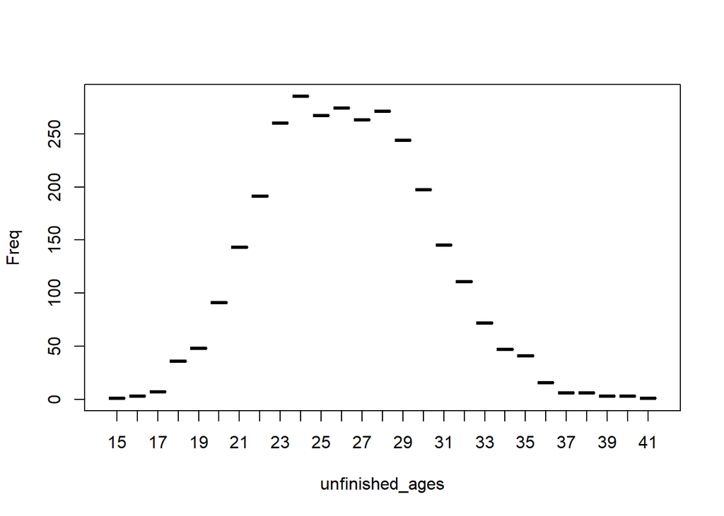

```r
unfinished_sets <- tennis[grepl("[A-Za-z]", tennis$score),]
unfinished_ages <- round(unfinished_sets[c("loser_age")])
grupirani_unf <- subset(as.data.frame(table(unfinished_ages)), Freq != 0)
plot(grupirani_unf)
```

Promatranje napretka najboljih igrača

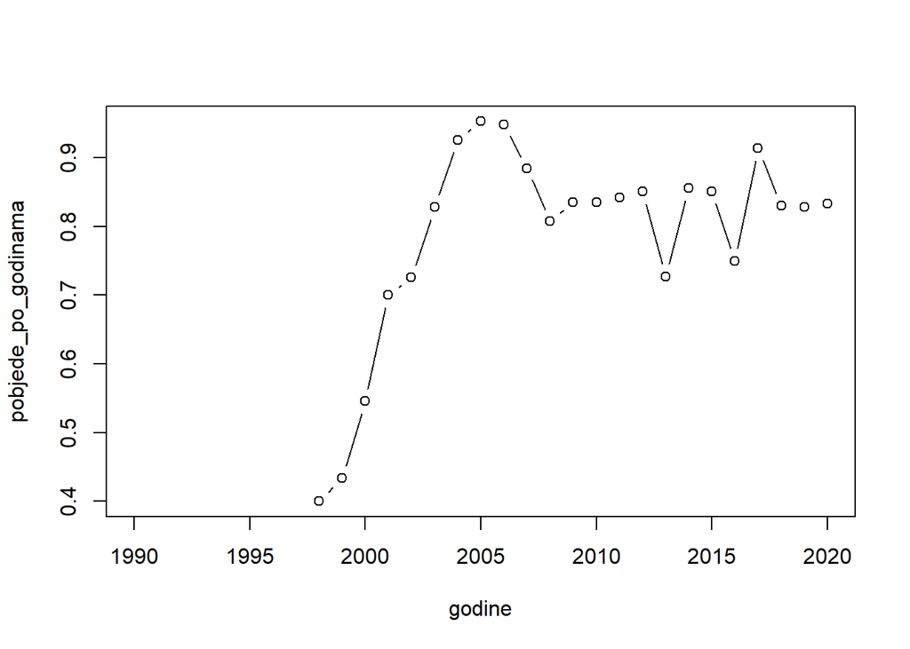

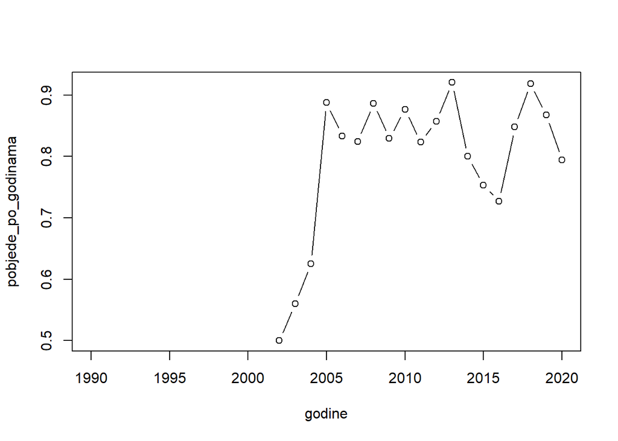

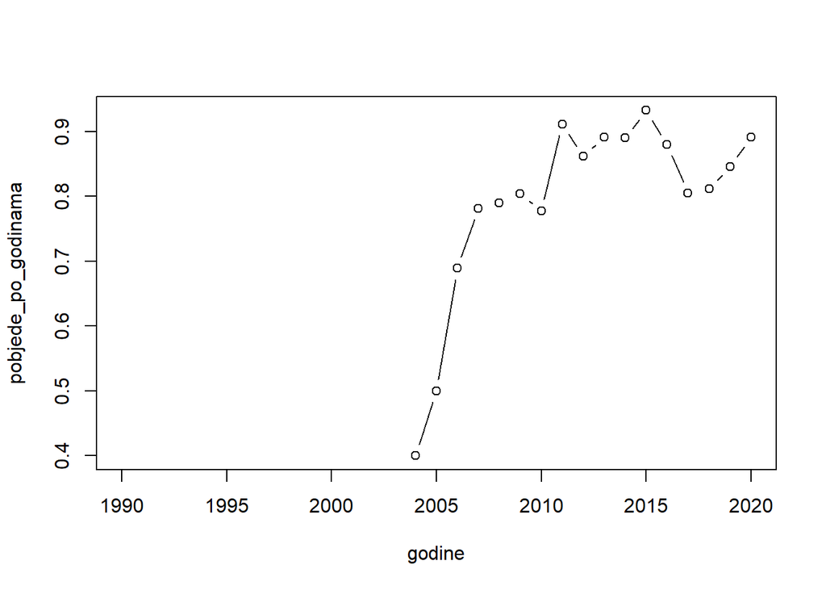

```r
tri_najbolja <- sort(table(tennis$winner_id), decreasing=TRUE)[1:3]
godine <- sort(unique(substr(tennis$tourney_date, 1, 4)))
for(player_id in dimnames(tri_najbolja)[[1]]) {
  pobjede_po_godinama <- rep()
  for(godina in godine) {
    pobjede_po_godinama <- append(pobjede_po_godinama, nrow(tennis[which(tennis$winner_id == player_id & substr(tennis$tourney_date, 1, 4) == godina),])
    / nrow(tennis[which((tennis$winner_id == player_id | tennis$loser_id == player_id) & substr(tennis$tourney_date, 1, 4) == godina),]))
  }
  plot(godine, pobjede_po_godinama, type="b")
}
```